# Análise Bi Objetivo

1. **Alocação Ótima por Cenário**
   - Para cada simulação (“sim1”, “sim2”, “sim3” e histórico), identifica a carteira que maximiza a relação retorno/risco.
   - Garante **mínimo de 5 %** em cada ativo e soma total de 100 %.
2. **Trade-off Risco × Retorno**
   - Mostra o **retorno esperado** e o **risco (σ)** diário de cada portfólio ótimo.
   - Calcula o **Sharpe Ratio** para comparar diretamente performance ajustada ao risco.
3. **Análise de Drawdown e Performance Cumulativa**
   - Exibe o **crescimento acumulado** do capital em 22 dias.
   - Destaca o **drawdown máximo** (queda percentual) que a carteira pode sofrer antes de recuperar.
4. **Visualizações Interativas**
   - Gráficos com **fronteira eficiente**, **simulações Monte Carlo**, **máximo Sharpe** e **bar chart** de pesos.
   - Drawdown e riqueza (wealth index) em painéis sincronizados.
5. **Tomada de Decisão Rápida**
   - Permite escolher o cenário (histórico ou simulado) que apresenta o melhor equilíbrio risco-retorno.
   - Informa se a volatilidade esperada e o drawdown máximo estão dentro da **tolerância** da sua estratégia de investimento.
   - Ajuda a justificar o peso de cada ativo com base em métricas sólidas e visuais claros.

🔑 **Em resumo:** o notebook dá um roteiro completo para  
- **quantificar** risco e retorno,  
- **comparar** cenários,  
- **escolher** alocações sólidas,  
- **monitorar** drawdown,  
conduzindo a decisões de investimento mais embasadas e transparentes.

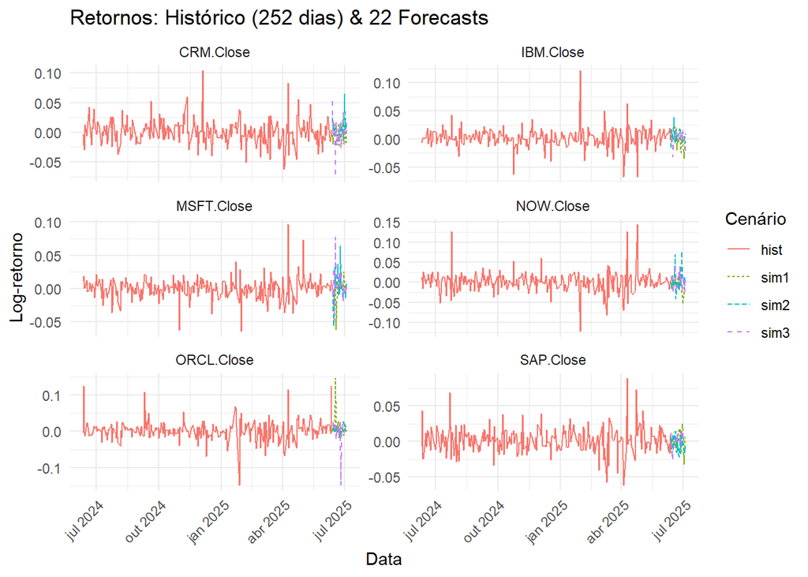

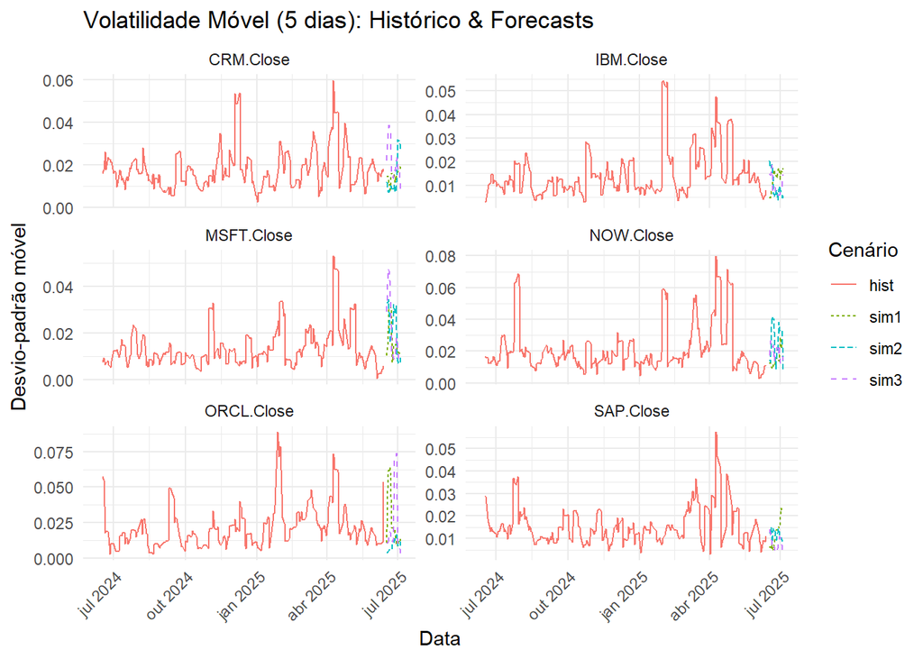

## Fronteiras Eficientes via Simulação de Monte Carlo e Plotly

### 1. Dados e Pré-processamento

- Lemos a planilha `retornos_e_volatilidades.xlsx`, que contém colunas `ret_<ativo>` com os **retornos diários simulados**.

### 2. Simulação de Carteiras Aleatórias

- Geramos $N=50\,000$ vetores de pesos:
- Para cada carteira (i), calculamos:
  - **Retorno esperado**
  - **Risco** (desvio‐padrão ou idealmente GARCH(1,1) com Student-t assimétrica)

### 3. Carteira de Máximo Sharpe

- O **índice de Sharpe** diário:
  $$S_i = \frac{R_i - R_f}{\sigma_i},
  \quad R_f = 0.$$

### 4. Fronteira Eficiente Empírica

Em cada um dos 4 subplots 2×2: - **Pontos cinza**: todas as simulações $(\sigma_i,R_i)$.  
- **Linha vermelha**: fronteira eficiente empírica.  
- **Estrela dourada**: carteira de máximo Sharpe.

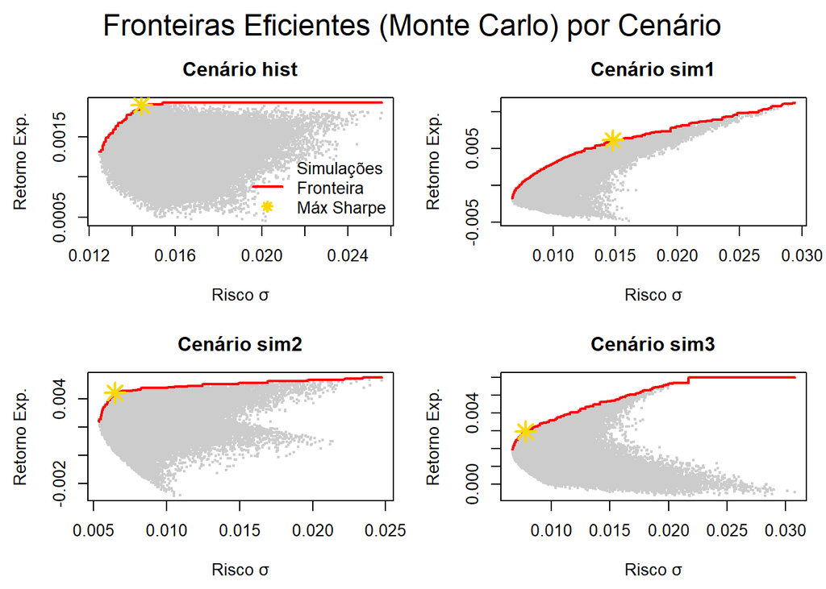

# Otimização Multi-Objetivo Markowitz via Evolução Diferencial (DE) — Cenário **sim1**

Este bloco implementa um modelo de alocação de portfólio que **minimiza risco** e **maximiza retorno** ao mesmo tempo, usando:

- **Modelo de Markowitz (Scalarizado)**
  - Um algoritmo genético de otimização numérica que explora **populações** de vetores para encontrar o vetor ótimo
  - A cada iteração, combina vetores, mutaciona, seleciona os melhores segundo a função-objetivo

## Resultados Esperados

[output not shown]

[output not shown]

[output cut: 945 more lines]

[output not shown]

```
=== Alocação Ótima (Markowitz via DE) — sim1 ===
```

```
  CRM.Close   :   8.35%
  IBM.Close   :  15.18%
  MSFT.Close  :  14.65%
  NOW.Close   :   5.29%
  ORCL.Close  :  17.04%
  SAP.Close   :  39.48%
```

```
Retorno Médio Diário: 0.1938%
```

```
Risco Diário (σ)    : 0.8782%
```

```
Sharpe (Rf=0)       : 0.2206
```

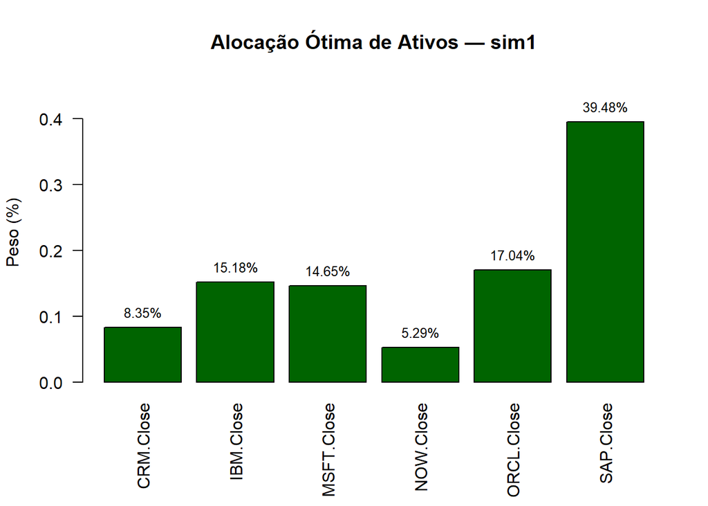

## Análise de Performance e Drawdown — Carteira Ótima (sim1)

[interactive chart not shown]

# Simulação Cenário 2

[output not shown]

[output cut: 945 more lines]

[output not shown]

```
=== Alocação Ótima (Markowitz via DE) — sim2 ===
```

```
  CRM.Close   :  13.75%
  IBM.Close   :  34.95%
  MSFT.Close  :   5.00%
  NOW.Close   :   5.00%
  ORCL.Close  :  36.30%
  SAP.Close   :   5.00%
```

```
Retorno Médio Diário: 0.3909%
```

```
Risco Diário (σ)    : 0.6088%
```

```
Sharpe (Rf=0)       : 0.6421
```

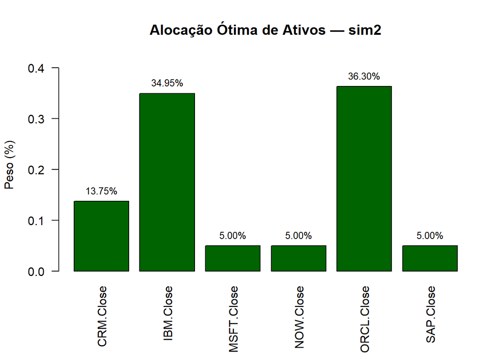

## Análise de Performance e Drawdown — Carteira Ótima (sim2)

[interactive chart not shown]

# Simulação Cenário 3

[output not shown]

[output cut: 945 more lines]

[output not shown]

```
=== Alocação Ótima (Markowitz via DE) — sim3 ===
```

```
  CRM.Close   :  15.56%
  IBM.Close   :   5.00%
  MSFT.Close  :  16.96%
  NOW.Close   :  12.71%
  ORCL.Close  :   5.00%
  SAP.Close   :  44.77%
```

```
Retorno Médio Diário: 0.2402%
```

```
Risco Diário (σ)    : 0.6874%
```

```
Sharpe (Rf=0)       : 0.3494
```

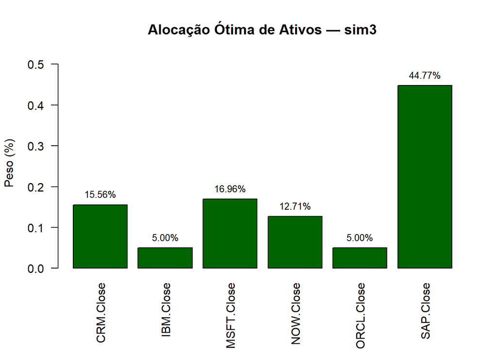

## Análise de Performance e Drawdown — Carteira Ótima (sim3)

[interactive chart not shown]